# STAT 425 Homework 7

Kefu Zhu, kefuzhu2

Tuesday, December 2, 2015

# Question 1

```r
library(faraway)
data("aflatoxin")
attach(aflatoxin)
```

**(a)**

```r
fit1 <-  glm(cbind(tumor,total - tumor) ~ dose,family = binomial)
summary(fit1)
```

```
##
## Call:
## glm(formula = cbind(tumor, total - tumor) ~ dose, family = binomial)
##
## Deviance Residuals:
##       1        2        3        4        5        6
## -1.2995   0.7959  -0.4814   0.4174  -0.1629   0.3774
##
## Coefficients:
##             Estimate Std. Error z value Pr(>|z|)
## (Intercept) -3.03604    0.48226  -6.295 3.07e-10 ***
## dose         0.09009    0.01456   6.189 6.04e-10 ***
## ---
## Signif. codes:  0 '***' 0.001 '**' 0.01 '*' 0.05 '.' 0.1 ' ' 1
##
## (Dispersion parameter for binomial family taken to be 1)
##
##     Null deviance: 116.524  on 5  degrees of freedom
## Residual deviance:   2.897  on 4  degrees of freedom
## AIC: 17.685
##
## Number of Fisher Scoring iterations: 5
```

**(b)**

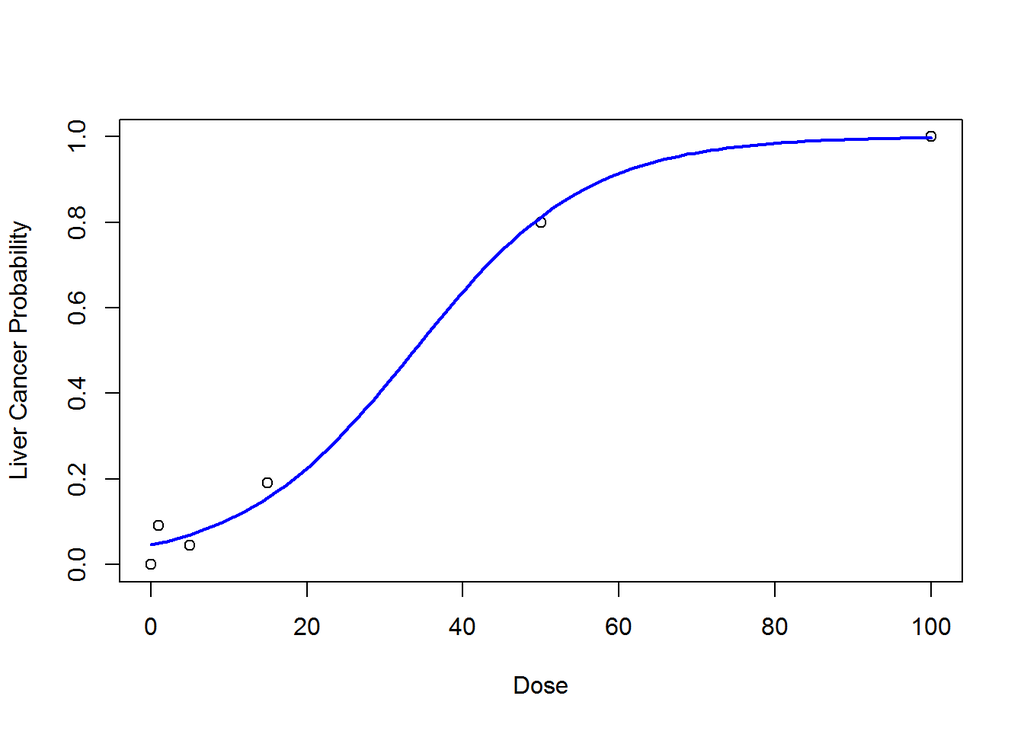

```r
plot(dose,tumor / total,xlab = 'Dose',ylab = 'Liver Cancer Probability')
x1 <- seq(0,100,length.out = 100)
lines(x1,predict(fit1,data.frame(dose = x1),type = 'response'),lwd=2,col = 'blue')
```

**(c)**

```r
predict(fit1,type='response')
```

```
##          1          2          3          4          5          6
## 0.04582416 0.04992838 0.07007143 0.15647348 0.81281443 0.99745948
```

```r
residuals(fit1)
```

```
##          1          2          3          4          5          6
## -1.2994857  0.7958584 -0.4814040  0.4173608 -0.1628644  0.3774260
```

**(d)**

```r
p1<-predict(fit1,data.frame(dose = 60),type='response')
p1
```

```
##         1
## 0.9144553
```

```r
odds<-p1/(1-p1)
odds
```

```
##       1
## 10.6898
```

**(e)**

```r
pchisq(deviance(fit1),df.residual(fit1),lower=FALSE)
```

```
## [1] 0.5752128
```

**My answer**: Since the p-value is 0.5752128, which is greater than any standard significance level, I conclude that there is no evidence of lack of fit.

**(f)**

```r
fit1.2<-glm(cbind(tumor,total - tumor) ~ log(dose+1),family = binomial)
summary(fit1.2)
```

```
##
## Call:
## glm(formula = cbind(tumor, total - tumor) ~ log(dose + 1), family = binomial)
##
## Deviance Residuals:
##        1         2         3         4         5         6
## -0.30928   2.35611  -0.49143  -1.35837  -0.08212   1.90296
##
## Coefficients:
##               Estimate Std. Error z value Pr(>|z|)
## (Intercept)    -5.9292     1.0256  -5.781 7.41e-09 ***
## log(dose + 1)   1.8711     0.3033   6.169 6.87e-10 ***
## ---
## Signif. codes:  0 '***' 0.001 '**' 0.01 '*' 0.05 '.' 0.1 ' ' 1
##
## (Dispersion parameter for binomial family taken to be 1)
##
##     Null deviance: 116.524  on 5  degrees of freedom
## Residual deviance:  11.362  on 4  degrees of freedom
## AIC: 26.15
##
## Number of Fisher Scoring iterations: 5
```

```r
pchisq(deviance(fit1.2),df.residual(fit1.2),lower=FALSE)
```

```
## [1] 0.02278691
```

**My answer**: Since the p-value of the lack of fit test is 0.0227869, I will conclude that there is evidence of lack of fit on 5% significance level. So the transformation is not good.

**(g)**

```r
fit1.3<-glm(cbind(tumor,total - tumor) ~ dose,family = binomial(link=probit))
summary(fit1.3)
```

```
##
## Call:
## glm(formula = cbind(tumor, total - tumor) ~ dose, family = binomial(link = probit))
##
## Deviance Residuals:
##        1         2         3         4         5         6
## -1.23164   0.89070  -0.47838   0.25563  -0.06575   0.12366
##
## Coefficients:
##              Estimate Std. Error z value Pr(>|z|)
## (Intercept) -1.736231   0.240449  -7.221 5.17e-13 ***
## dose         0.051933   0.007873   6.596 4.22e-11 ***
## ---
## Signif. codes:  0 '***' 0.001 '**' 0.01 '*' 0.05 '.' 0.1 ' ' 1
##
## (Dispersion parameter for binomial family taken to be 1)
##
##     Null deviance: 116.5243  on 5  degrees of freedom
## Residual deviance:   2.6241  on 4  degrees of freedom
## AIC: 17.413
##
## Number of Fisher Scoring iterations: 5
```

```r
pchisq(deviance(fit1.3),df.residual(fit1.3),lower=FALSE)
```

```
## [1] 0.6225645
```

**My answer**: Since the p-value is 0.6225645, which is greater than any standard significance level, I conclude that there is no evidence of lack of fit.

# Question 2

```r
data(wbca)
attach(wbca)
```

**(a)**

```r
fit2<-glm(Class~.,family=binomial,data=wbca)
summary(fit2)
```

```
##
## Call:
## glm(formula = Class ~ ., family = binomial, data = wbca)
##
## Deviance Residuals:
##      Min        1Q    Median        3Q       Max
## -2.48282  -0.01179   0.04739   0.09678   3.06425
##
## Coefficients:
##             Estimate Std. Error z value Pr(>|z|)
## (Intercept) 11.16678    1.41491   7.892 2.97e-15 ***
## Adhes       -0.39681    0.13384  -2.965  0.00303 **
## BNucl       -0.41478    0.10230  -4.055 5.02e-05 ***
## Chrom       -0.56456    0.18728  -3.014  0.00257 **
## Epith       -0.06440    0.16595  -0.388  0.69795
## Mitos       -0.65713    0.36764  -1.787  0.07387 .
## NNucl       -0.28659    0.12620  -2.271  0.02315 *
## Thick       -0.62675    0.15890  -3.944 8.01e-05 ***
## UShap       -0.28011    0.25235  -1.110  0.26699
## USize        0.05718    0.23271   0.246  0.80589
## ---
## Signif. codes:  0 '***' 0.001 '**' 0.01 '*' 0.05 '.' 0.1 ' ' 1
##
## (Dispersion parameter for binomial family taken to be 1)
##
##     Null deviance: 881.388  on 680  degrees of freedom
## Residual deviance:  89.464  on 671  degrees of freedom
## AIC: 109.46
##
## Number of Fisher Scoring iterations: 8
```

**(b)** **My answer**: It is not appropriate to perform the lack-of-fit test, because the data is binary which means all $n_{i} = 1$.

**(c)**

```r
data<-data.frame(Adhes=1, BNucl=1, Chrom=2,Epith=2, Mitos=1, NNucl=1, Thick=2, UShap=1, USize=1)
tmp<-predict(fit2,data,se.fit=TRUE)
tmp
```

```
## $fit
##        1
## 6.677113
##
## $se.fit
## [1] 0.7926542
##
## $residual.scale
## [1] 1
```

```r
1-ilogit(c(tmp$fit-1.96*tmp$se.fit, tmp$fit+1.96*tmp$se.fit))
```

```
##            1            1
## 0.0059198246 0.0002662748
```

**(d)**

```r
mean((fitted(fit2) > 0.5) != Class)
```

```
## [1] 0.02790015
```

**My answer**: About 3% of the observations would be misclassified.

**(e)**

```r
reduce_model <- step(fit2,direction = 'backward')
```

```
## Start:  AIC=109.46
## Class ~ Adhes + BNucl + Chrom + Epith + Mitos + NNucl + Thick +
##     UShap + USize
##
##         Df Deviance    AIC
## - USize  1   89.523 107.52
## - Epith  1   89.613 107.61
## - UShap  1   90.627 108.63
## <none>       89.464 109.46
## - Mitos  1   93.551 111.55
## - NNucl  1   95.204 113.20
## - Adhes  1   98.844 116.84
## - Chrom  1   99.841 117.84
## - BNucl  1  109.000 127.00
## - Thick  1  110.239 128.24
##
## Step:  AIC=107.52
## Class ~ Adhes + BNucl + Chrom + Epith + Mitos + NNucl + Thick +
##     UShap
##
##         Df Deviance    AIC
## - Epith  1   89.662 105.66
## - UShap  1   91.355 107.36
## <none>       89.523 107.52
## - Mitos  1   93.552 109.55
## - NNucl  1   95.231 111.23
## - Adhes  1   99.042 115.04
## - Chrom  1  100.153 116.15
## - BNucl  1  109.064 125.06
## - Thick  1  110.465 126.47
##
## Step:  AIC=105.66
## Class ~ Adhes + BNucl + Chrom + Mitos + NNucl + Thick + UShap
##
##         Df Deviance    AIC
## <none>       89.662 105.66
## - UShap  1   91.884 105.88
## - Mitos  1   93.714 107.71
## - NNucl  1   95.853 109.85
## - Adhes  1  100.126 114.13
## - Chrom  1  100.844 114.84
## - BNucl  1  109.762 123.76
## - Thick  1  110.632 124.63
```

```r
summary(reduce_model)
```

```
##
## Call:
## glm(formula = Class ~ Adhes + BNucl + Chrom + Mitos + NNucl +
##     Thick + UShap, family = binomial, data = wbca)
##
## Deviance Residuals:
##      Min        1Q    Median        3Q       Max
## -2.44161  -0.01119   0.04962   0.09741   3.08205
##
## Coefficients:
##             Estimate Std. Error z value Pr(>|z|)
## (Intercept)  11.0333     1.3632   8.094 5.79e-16 ***
## Adhes        -0.3984     0.1294  -3.080  0.00207 **
## BNucl        -0.4192     0.1020  -4.111 3.93e-05 ***
## Chrom        -0.5679     0.1840  -3.085  0.00203 **
## Mitos        -0.6456     0.3634  -1.777  0.07561 .
## NNucl        -0.2915     0.1236  -2.358  0.01837 *
## Thick        -0.6216     0.1579  -3.937 8.27e-05 ***
## UShap        -0.2541     0.1785  -1.423  0.15461
## ---
## Signif. codes:  0 '***' 0.001 '**' 0.01 '*' 0.05 '.' 0.1 ' ' 1
##
## (Dispersion parameter for binomial family taken to be 1)
##
##     Null deviance: 881.388  on 680  degrees of freedom
## Residual deviance:  89.662  on 673  degrees of freedom
## AIC: 105.66
##
## Number of Fisher Scoring iterations: 8
```

# Question 3

```r
data(turtle)
attach(turtle)
```

**(a)**

```r
fit3<-glm(cbind(male,female)~temp,family=binomial)
summary(fit3)
```

```
##
## Call:
## glm(formula = cbind(male, female) ~ temp, family = binomial)
##
## Deviance Residuals:
##     Min       1Q   Median       3Q      Max
## -2.0721  -1.0292  -0.2714   0.8087   2.5550
##
## Coefficients:
##             Estimate Std. Error z value Pr(>|z|)
## (Intercept) -61.3183    12.0224  -5.100 3.39e-07 ***
## temp          2.2110     0.4309   5.132 2.87e-07 ***
## ---
## Signif. codes:  0 '***' 0.001 '**' 0.01 '*' 0.05 '.' 0.1 ' ' 1
##
## (Dispersion parameter for binomial family taken to be 1)
##
##     Null deviance: 74.508  on 14  degrees of freedom
## Residual deviance: 24.942  on 13  degrees of freedom
## AIC: 53.836
##
## Number of Fisher Scoring iterations: 5
```

**(b)**

```r
pchisq(deviance(fit3),df.residual(fit3),lower=FALSE)
```

```
## [1] 0.02348863
```

**My answer**: Since the p-value is 0.0234886, I conclude that there is evidence of lack of fit on 5% significance level.

**(c)**

```r
pearson_statistic <- sum(residuals(fit3,type="pearson")^2)
pearson_statistic
```

```
## [1] 26.24234
```

```r
pchisq(pearson_statistic,df.residual(fit3),lower=FALSE)
```

```
## [1] 0.01577083
```

**My answer**: Since the p-value is 0.0157708, I conclude that there is evidence of lack of fit on 5% significance level.

**(d)**

```r
pearson_statistic/(fit3$df.null+1-(length(fit3$coefficients)))
```

```
## [1] 2.018641
```

**(e)**

```r
summary(fit3,dispersion = 2.018641)
```

```
##
## Call:
## glm(formula = cbind(male, female) ~ temp, family = binomial)
##
## Deviance Residuals:
##     Min       1Q   Median       3Q      Max
## -2.0721  -1.0292  -0.2714   0.8087   2.5550
##
## Coefficients:
##             Estimate Std. Error z value Pr(>|z|)
## (Intercept) -61.3183    17.0812  -3.590 0.000331 ***
## temp          2.2110     0.6122   3.612 0.000304 ***
## ---
## Signif. codes:  0 '***' 0.001 '**' 0.01 '*' 0.05 '.' 0.1 ' ' 1
##
## (Dispersion parameter for binomial family taken to be 2.018641)
##
##     Null deviance: 74.508  on 14  degrees of freedom
## Residual deviance: 24.942  on 13  degrees of freedom
## AIC: 53.836
##
## Number of Fisher Scoring iterations: 5
```

**My answer**: The estimates of coefficient do not change, but the standard errors increase.